# [PD2] Frelik Stanisław

Stanislaw Frelik

2023-03-15

Jak dobrze wiemy skoro tyle się trzeba napracować żeby w ggplocie narysować wykres kołowy to znaczy, iż może lepiej ich w ogólności nie rysować. Pomimo swoich wyraźnych walorów estetycznych wykresy kołowe często sprawiają odbiorcy kłopot w dokładniejszej analizie podpierających je danych. Taki właśnie przypadek chciałbym zaprezentować.

Skupię się na wykresie stworzonym przez użytkownika u/Crash_Recovery, który 10 marca bieżącego roku zaprezentował na r/dataisbeautiful swoją [pracę - link](https://www.reddit.com/r/dataisbeautiful/comments/11nt9ue/john_wicks_weapon_usage_original_trilogy_oc/). Dotyczy ona między innymi rodzajów broni jakimi posługiwał się głowny bohater trylogii o Johnym Wicku, to znaczy jakimi narzędziami “rozprawiał” się on ze swoimi przeciwnikami…

Wspomniany wyżej autor zdecydował się stworzyć wykres kołowy, na którym poszczególne obszary przedstawiały jaki udział miały poszczególne bronie w ogólnej liczbie “killi” bohatera.

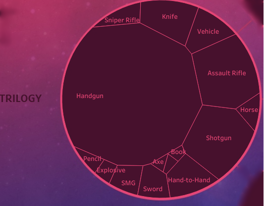

Korzystając więc z danych z [Kaggle](https://www.kaggle.com/datasets/zbowders/john-wicks-confirmed-onscreen-kills) chciałbym zaprezentować moje spojrzenie na nie, mam nadzieje, bardziej czytelne.

[figure not shown]

```r
library(dplyr)
library(ggplot2)
library(png)
library(ggpubr)

WickPic <- readPNG("WicPick.png")
WICK <- read.csv("JohnWick.csv")

WICK %>%
  select(Weapon) %>%
  filter(Weapon != "") %>%
  ggplot(aes(x = reorder(Weapon, Weapon, function(x)-length(x)))) +
  scale_x_discrete(guide = guide_axis(n.dodge = 2)) +
  scale_y_continuous(expand = expansion(mult = c(0.01, .1))) +
  background_image(WickPic) +
  geom_bar() +
  geom_text(aes(label = ..count..),
            stat = "count",
            vjust = -0.7,
            colour = "red",
            size = 4.5) +
  labs(title = "John Wick's Weapon Usage - Original Trilogy",
       x = "", y = "",
       caption = "grafika: https://www.monolith.pl/filmy/2016/john-wick-2/")
```

Mam nadzieję, że udało mi się osiągnąć pewne walory estetyczne :) oraz że wykres jasno przekazuje interesujące nas dane - wyraźnie widzimy “ile - czego jest” oraz wzajemne relacje pomiędzy “narzędziami” stały się dobitnie widoczne.

Dziękuję za uwagę!